#### New to Plotly?

Plotly's Python library is free and open source! [Get started](https://plotly.com/python/getting-started/) by downloading the client and [reading the primer](https://plotly.com/python/getting-started/).  
You can set up Plotly to work in [online](https://plotly.com/python/getting-started/#initialization-for-online-plotting) or [offline](https://plotly.com/python/getting-started/#initialization-for-offline-plotting) mode, or in [jupyter notebooks](https://plotly.com/python/getting-started/#start-plotting-online).  
We also have a quick-reference [cheatsheet](https://images.plotly.com/plotly-documentation/images/python_cheat_sheet.pdf) (new!) to help you get started!

#### Version Check

Plotly's python package is updated frequently. Run `pip install plotly --upgrade` to use the latest version.

```python
import plotly
plotly.__version__
```

```
'3.6.1'
```

#### Plotly Offline from Command Line

You can plot your graphs from a python script from command line. On executing the script, it will open a web browser with your Plotly Graph drawn.

```python
import plotly.graph_objs as go
from plotly.offline import download_plotlyjs, init_notebook_mode, plot, iplot

plot([go.Scatter(x=[1, 2, 3], y=[3, 1, 6])])
```

```
'file:///Users/Chelsea/Repos/documentation/_posts/python/offline/temp-plot.html'
```

#### Generating Offline Graphs within Jupyter Notebook

You can also plot your graphs offline inside a Jupyter Notebook Environment. First you need to initiate the Plotly Notebook mode as below:

```python
init_notebook_mode(connected=True)
```

Run at the start of every ipython notebook to use plotly.offline. This injects the plotly.js source files into the notebook.

```python
iplot([{"x": [1, 2, 3], "y": [3, 1, 6]}])
```

[interactive chart not shown]

```python
import plotly.graph_objs as go

import numpy as np

x = np.random.randn(2000)
y = np.random.randn(2000)
iplot([go.Histogram2dContour(x=x, y=y, contours=dict(coloring='heatmap')),
       go.Scatter(x=x, y=y, mode='markers', marker=dict(color='white', size=3, opacity=0.3))], show_link=False)
```

[interactive chart not shown]

#### Plotting Offline with Cufflinks

```python
import cufflinks as cf

iplot(cf.datagen.lines().iplot(asFigure=True,
                               kind='scatter',xTitle='Dates',yTitle='Returns',title='Returns'))
```

[interactive chart not shown]

#### Use with the Cloud

All methods in plotly.plotly will communicate with a Chart Studio Cloud or Chart Studio Enterprise.  
`get_figure` downloads a figure from plotly.com or Chart Studio Enterprise.  
You need to provide credentials to download figures: https://plotly.com/python/getting-started/

```python
import plotly.plotly as py

fig = py.get_figure('https://plotly.com/~jackp/8715', raw=True)
iplot(fig)
```

[interactive chart not shown]

#### Static Image Export

The `plotly.io.to_image` function can then be used to convert a plotly figure to a static image bytes string.

```python
import plotly.io as pio

static_image_bytes = pio.to_image(fig, format='png')
```

Use `IPython.display.Image` to display the image bytes as image in the notebook

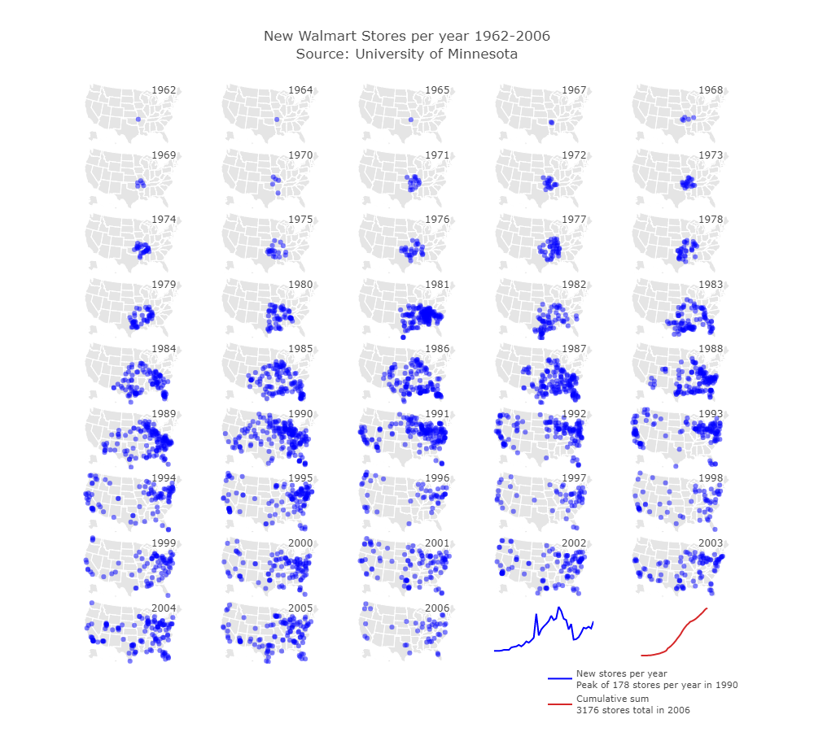

```python
from IPython.display import Image

Image(static_image_bytes)
```

Use `plotly.io.write_image` to convert a figure to a static image and write it to a file or writeable object.

Make sure to add a file extension or specify the file type using the format parameter.

```python
pio.write_image(fig, file='plotly_static_image.png', format='png')
```

### Reference

For more information, run `help(plotly.offline.iplot)` or `help(plotly.offline.plot)` or `help(plotly.io.to_image)` or `help(plotly.io.write_image)`